# Using energy balances to estimate body temperatures

## Nocturnal Salamanders (humid operative temperatures)

We present a function `Tb_salamander_humid` adapted from Riddell et al. (2018) and Campbell and Norman (2012) that calculates the humid operative temperature ($T_{eh}$) of a nocturnal salamander. The function estimates $T_{eh}$ by accounting for evaporative cooling from the high water loss rates typically associated with amphibians. Rates of evaporative cooling are primarily a function of the humidity in the air and the resistance of the skin to water loss. The vapor pressure deficit ($D$) describes the drying power of the ambient air and thus the potential for evaporative cooling.

Similarly, the skin resistance to water loss ($r_{i}$) describes the capacity of the integument to resist the flux of water given the gradient of humidity in ambient air. High rates of water loss, for instance, can occur if humidity or skin resistance to water loss is low, resulting in greater amounts of evaporative cooling. The model also incorporates additional variables, such as nighttime absorbed radiation, radiative conductance, elevation, and boundary layer resistance. Direct and indirect solar radiation are not included because the code was developed for a nocturnal species. In addition to the cooling effect from evaporation, operative temperatures ($T_{e}$) at night are also generally lower than air temperatures due to emitted radiation being larger than absorbed (Campbell and Norman 2012).

The $T_{eh}$ function is defined as
$$T_{eh}=T_{a}+\frac{\gamma^{*}}{s+\gamma^{*}} \left( \frac{R_{abs} - \epsilon_{s}\sigma T^{4}_{a}}{c_{p}g_{Hr}} -\frac{D} {\gamma^{*}p_{a}} \right)$$
where $T_{a}$ is the air temperature in Celsius, $\gamma^{*}$ is the apparent psychrometer constant ($C^{-1}$), $s$ is the slope of the saturation mole fraction function ($C^{-1}$), $R_{abs}$ is the absorbed radiation ($W\:m^{-2}$), $\epsilon _{s}$ is the emissivity of the surface, $\sigma$ is the Stefan-Boltzmann constant ($W\:m^{−2}\:C^{−4}$), $c_{p}$ is specific heat of air (29.3 $J\:mol^{-1}\:C^{-1}$), $g_{Hr}$ is the sum of boundary layer conductance for heat and radiative conductance ($mol\:m^{-2}\:s^{-1}$), $D$ is the vapor pressure deficit (vpd, kPa), and $p_{a}$ is the atmospheric pressure (kPa).

To calculate $s$, we use $s=\Delta/p_{a}$ where $\Delta$ is the slope of saturation vapor pressure.  
We calculate $\Delta$ using

$$\Delta = \frac{bce_{s}(T)}{(c+T)^2}$$

where $b = 17.502$, $c = 240.97^{\circ}C$, $e_s(T)$ is the saturation vapor pressure of the air ($kPa$), and T is temperature in Celsius. For $p_a$ we use

$$p_{a}= 101.3exp\Big(\frac{-A}{8200}\Big)$$

where $A$ is the altitude in meters above sea level and $p_{a}$ is in $kPa$. For $e_s{s}$ we use
$$e_{s}(T)=a\:exp\ Big(\frac{bT}{T+c}\Big)$$
where $a$ is 0.611 kPa and $T$ is the temperature in Celsius.

For $\gamma^{*}$, we use
$$\gamma^{*}=\frac{\gamma(1/g_{vs} + 1/g_{vc}+1/g_{va})} {1/g_{Hc}+1/g_{Hr}}$$
where $\gamma$ is the thermodynamic psychrometer constant, which is $6.66 \times 10^{-4}C^{-1}$ (Campbell and Norman 2012), $g_{vs}$ is the conductance of the skin to vapor ($mol\:m^{−2}\:s^{−1}$), $g_{vc}$ is the conductance of the coat to vapor ($mol\:m^{−2}\:s^{−1}$), $g_{va}$ is the boundary layer conductance for vapor ($mol\:m^{−2}\:s^{−1}$), $g_{Hc}$ is the conductance of the coat for heat ($mol\:m^{−2}\:s^{−1}$), and $g_{Hr}$ is the sum of boundary layer conductance for heat and radiative conductance ($mol\:m^{−2}\:s^{−1}$).

Both $1/g_{Hc}$ and $1/g_{vc}$ are assumed to be zero since salamanders do not have insulation, such as fur, feathers, or clothing. Thus, $\gamma^{*}$ can also be calculated as $\gamma^{*}=\gamma H_{r}/g_{v}$ where $g_{v}$ is the total vapor conductance ($mol\:m^{−2}\:s^{−1}$). We calculate $g_{v}$ using

$$g_{v}=\frac{g_{vs} g_{va}}{g_{vs}+g_{va}}.$$

We convert skin and boundary layer resistance for vapor to conductance by multiplying the values by 100 to convert to $s\:m^{-2}$ and then dividing by 41.1 $mol\:m^{-3}$. The boundary layer conductance for heat is calculated as $g_{Ha}= 1.4*0.135*sqrt(u/d)$, where $u$ is the wind speed $(m/s)$ and $d$ is the characteristic dimension $(m)$. We use a wind speed 0.1 m/s in our calculations of $g_{Ha}$ to mimic still air near the ground (Campbell and Norman 2012), and for $D$ the cross-sectional diameter of a cylinder approximating the size of a salamander. Boundary layer resistance can be estimated as follows.

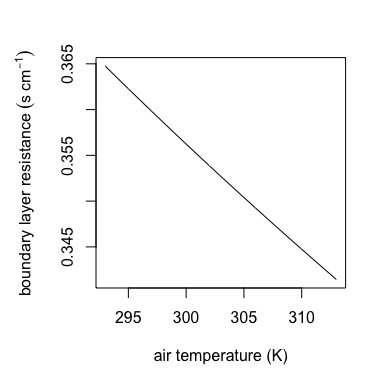

```r
par(mar = c(5,  5, 3, 2))
blr.seq= lapply(293:313, FUN=boundary_layer_resistance, e_s= 2.5, e_a = 2.3, elev = 500, D = 0.007, u = 2)
plot(x    = 293:313,
     y    = blr.seq,
     type = "l",
     xlab = "air temperature (K)",
     ylab = expression("boundary layer resistance" ~ (s ~ cm^{-1})))
```

TrenchR includes several support functions, often adapted from Campbell and Norman (2012), used for estimating humid operative temperatures. Functions estimate thermal radiation absorbed (`thermal_radiation_absorbed`) and emitted (`Qemitted_thermal_radiation`) as well as actual (`actual_vapor_pressure`) and saturation (`saturation_vapor_pressure`) vapor pressure. The functions also include a statistical approximation from Campbell and Norman (2012) for estimating soil temperatures at specified depths.

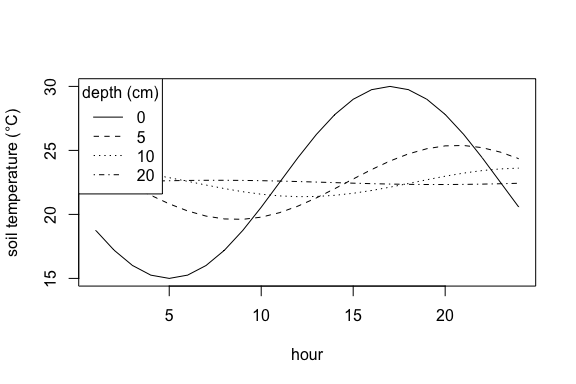

```r
plot(x    = 1:24,
     y    = Tsoil(T_g_max = 30,
                  T_g_min = 15,
                  hour    = 1:24,
                  depth   = 0),
     type = "l",
     xlab = "hour",
     ylab = "soil temperature (°C)")

points(x    = 1:24,
       y    = Tsoil(T_g_max = 30,
                    T_g_min = 15,
                    hour    = 1:24,
                    depth   = 5),
       type = "l",
       lty  = "dashed")

points(x    = 1:24,
       y    = Tsoil(T_g_max = 30,
                    T_g_min = 15,
                    hour    = 1:24,
                    depth   = 10),
       type = "l",
       lty  = "dotted")

points(x    = 1:24,
       y    = Tsoil(T_g_max = 30,
                    T_g_min = 15,
                    hour    = 1:24,
                    depth   = 20),
       type = "l",
       lty  = "dotdash")

legend(x      = "topleft",
       title  = "depth (cm)",
       legend = c(0,5,10,20),
       lty    = c("solid", "dashed", "dotted", "dotdash"))
```

We illustrate the humid operative temperature model by comparing an example parameterization (solid lines) to a 1:1 line (dotted line) indicating when humid operative temperatures equal air temperatures. Evaporative cooling lowers humid operative temperatures below air temperatures for the nocturnal salamander. Higher skin resistance to evaporation reduced cooling (red) whereas higher vapor pressure deficit augments cooling (blue).

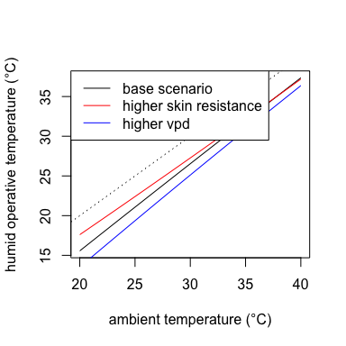

```r
rad.seq <- sapply(20:40,
                  FUN            = Qthermal_radiation_absorbed,
                  T_g            = 30,
                  epsilon_ground = 0.97,
                  a_longwave     = 0.965)

t.seq <- mapply(FUN     = Tb_salamander_humid,
                T_a     = 20:40,
                r_i     = 4,
                r_b     = 1,
                D       = 0.01,
                elev    = 500,
                e_a     = 1.5,
                e_s     = 2.5,
                Qabs    = rad.seq,
                epsilon = 0.96)

plot(x    = 20:40,
     y    = t.seq,
     type = "l",
     xlab = "ambient temperature (°C)", ylab = "humid operative temperature (°C)")

abline(a    = 0,
       b    = 1,
       lty  = "dotted")

# check higher skin resistance-> Te closer to air due to reduced cooling

  t.seq <- mapply(FUN     = Tb_salamander_humid,
                  T_a     = 20:40,
                  r_i     = 20,
                  r_b     = 1,
                  D       = 0.01,
                  elev    = 500,
                  e_a     = 1.5,
                  e_s     = 2.5,
                  Qabs    = rad.seq,
                  epsilon = 0.96)
  points(x    = 20:40,
         y    = t.seq,
         type = "l",
         col  = "red")

# check higher vpd-> lower Te due to greater cooling

  t.seq <- mapply(FUN     = Tb_salamander_humid,
                  T_a     = 20:40,
                  r_i     = 4,
                  r_b     = 1,
                  D       = 0.01,
                  elev    = 500,
                  e_a     = 1.0,
                  e_s     = 2.5,
                  Qabs    = rad.seq,
                  epsilon = 0.96)
  points(x    = 20:40,
         y    = t.seq,
         type = "l",
         col  = "blue")

legend(x      = "topleft",
       title  = NULL,
       legend = c("base scenario", "higher skin resistance", "higher vpd"),
       lty    = c("solid"),
       col    = c("black", "red", "blue"))
```

# Example operative environmental temperature calculations

Suppose we want to estimate the hourly body temperature (operative environmental temperature, $T_e$) of a *Sceloporus* lizard on June 1, 2021, in Santa Fe, New Mexico, USA (35.69, -105.944, elevation: 2121m). Let’s assume the lizard is in an unshaded location where the daily air temperature varies from a minimum of 10°C to a maximum of 25°C, the soil surface temperature varies from a minimum of 15°C to a maximum of 30°C, and the windspeed is 0.5 m/s. We assume that atmospheric transmissivity $\tau = 0.7$ and albedo $\rho= 0.6$.

We will initially estimate $T_b$ by balancing an energy balance for steady-state conditions. We then use the $T_b$ estimates to explore the components of an energy balance.

## Environmental data

Let us first prepare the environmental data for analysis. We will need to estimate hourly air and soil temperatures and radiation. We start by estimating day of year and the timing of sunrise and sunset:

```r
# set up input data as variables
# latitude and longitude (degrees) and elevation (m)

  lat  <- 35.69
  lon  <- -105.944
  elev <- 2121

# minimum and maximum of air and soil temperatures, respectively (C)

  Tmin   <- 10
  Tmax   <- 25
  Tmin_s <- 15
  Tmax_s <- 30

# wind speed (m/s)

  u <- 0.5

# assumptions
#  atmospheric transmissivity and albedo

  tau <- 0.7
  rho <- 0.6

# initial assumption of body temperature (C)

  Tb0 <- 25

  doy   <- day_of_year("2021-06-01",
                       format= "%Y-%m-%d")
  snoon <- solar_noon(lon = lon,
                      doy = doy)
  dayl  <- daylength(lat = lat,
                     doy = doy)

# time of sunrise

  tr <- snoon - dayl / 2

# time of sunset

  ts <- snoon + dayl / 2
```

While measured solar radiation is preferable if available, we can estimate hourly solar radiation by discounting incoming solar radiation as it moved through the atmosphere as follows:

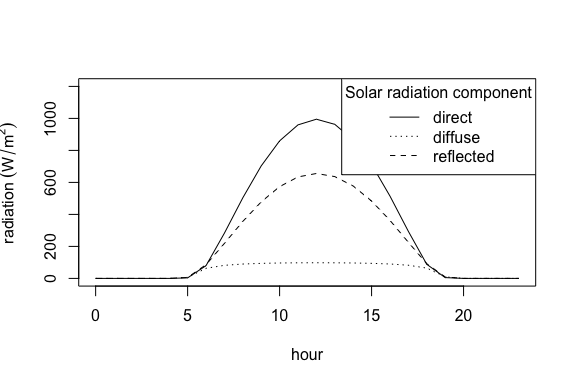

```r
psi_deg <- sapply(0:23,
                  FUN = zenith_angle,
                  doy = doy,
                  lat = lat,
                  lon = lon)

psi_rad <- degrees_to_radians(psi_deg)

Srad <- sapply(psi_rad,
               FUN  = solar_radiation,
               doy  = doy,
               tau  = tau,
               elev = elev,
               rho  = rho)

# Separate into direct, diffuse, and reflected solar radiation

  Sdir <- Srad[1,]
  Sdif <- Srad[2,]
  Sref <- Srad[3,]

plot(x    = 0:23,
     y    = Sdir,
     type = "l",
     xlab = "hour",
     ylab = expression(radiation ~ (W/m^{2})),
     ylim = c(0,1200))

points(x    = 0:23,
       y    = Sdif,
       type = "l",
       lty  = "dotted")

points(x    = 0:23,
       y    = Sref,
       type = "l",
       lty  = "dashed")

legend(x      = "topright",
       title  = "Solar radiation component",
       legend = c("direct", "diffuse", "reflected"),
       lty    = c("solid", "dotted", "dashed"))
```

We can then calculate hourly air and soil temperatures. We use the sine-exponential model for air temperature and the sine model for surface temperature:

```r
Ta <- sapply(0:23,
             FUN   = diurnal_temp_variation_sineexp,
             T_max = Tmax,
             T_min = Tmin,
             t_r   = tr,
             t_s   = ts,
             alpha = 2.59,
             beta  = 1.55,
             gamma = 2.2) #air temperature (C)

Ts <- sapply(0:23,
             FUN   = diurnal_temp_variation_sine,
             T_max = Tmax_s,
             T_min = Tmin_s) #soil temperature (C)
```

## Operative temperature estimation

We will first use functions based on energy balances to estimate body temperature given the environmental conditions. We first need to estimate several energy balance parameters. We first estimate the surface area exposed to radiation We model a 10g *Sceloporus* lizard with solar absorptivity $a = 0.9$ (Gates 2012).

```r
mass <- 10 #grams

# solar absorptivity

  a <- 0.9

# estimate surface area (m^2) from mass (g)

  A <- surface_area_from_mass(m     = mass,
                              taxon = "lizard")

# estimate projected (silhouette) area as a portion of surface area

  psa <- sapply(psi_deg,
                FUN     = proportion_silhouette_area,
                taxon   = "lizard",
                posture = "elevated")

# change negative values to zero

  psa[psa < 0] <- 0

# proportion of surface area in contact with ground, assume 0.25

  psa_g= 0.25

# Total radiation

  Qabs <- psa * Sdir + 0.5 * Sdif + (0.5-psa_g) * Sref
```

We then estimate the lizard’s heat transfer coefficient, $H_L$ using an empirical relationship for lizards (`heat_transfer_coefficient()`), but also illustrate a function estimating $H_L$ using a spherical approximation (`heat_transfer_coefficient_approximation()`) and a simplified approximation (`heat_transfer_coefficient_simple()`).

```r
# Use DRYAIR from NicheMapR to estimate the thermal conductivity of air and kinematic viscosity
# estimate Barometric pressure (pascal)

  ap <- airpressure_from_elev(elev) * 1000

  DRYAIRout <- DRYAIR(db  = Ta,
                      bp  = ap,
                      alt = elev)

  # thermal conductivity (Wm^-2K^-1)

    K   <- DRYAIRout$thcond

  # kinematic viscosity (m2 s-1)

    nu  <- DRYAIRout$viskin

  # approximate snout vent length (m) for Sceloporus

    svl <- 0.006

  # approximate characteristic dimension as cube root of volume, assuming density of water as 1000kg/m^3

    D <- ((mass / 1000) / 1000) ^ (1 / 3)

  # We will use the average of K and nu across the day for simplicity and since there's not a substantial variation

    K  <-  mean(K)
    nu <- mean(nu)

  # Estimate the heat transfer coefficient using an empirical relationship for lizards

    H_L <- heat_transfer_coefficient(u     = u,
                                     D     = D,
                                     K     = 25.7 * 10^(-3),
                                     nu    = 15.3 * 10^(-6),
                                     taxon = "lizard_surface")

  # Also illustrate estimations using a spherical approximation and a simplified version of the approximation.

    heat_transfer_coefficient_approximation(u     = u,
                                            D     = D,
                                            K     =  25.7 * 10^(-3),
                                            nu    = 15.3 * 10^(-6),
                                            taxon = "lizard")
```

```
## [1] 34.14719
```

```r
    heat_transfer_coefficient_simple(u    = 0.5,
                                     D    = D,
                                     type = "Spotila")
```

```
## [1] 20.73182
```

We now implement the first energy balance.

```r
epsilon_s <- 0.965

TeGates <- rep(NA, 24)

for (hr in 1:24) {
  TeGates[hr] <- Tb_Gates(A       = A,
                          D       = D,
                          psa_dir = psa[hr],
                          psa_ref = 0.5 -psa_g,
                          psa_air = 0.5,
                          psa_g   = psa_g,
                          T_g     = Ts[hr],
                          T_a     = Ta[hr],
                          Qabs    = Qabs[hr]*A,
                          epsilon = epsilon_s,
                          H_L     = H_L,
                          ef      = 1.3,
                          K       = 0.5)
}
```

We also implement a similar but simplified energy balance. The energy balance omits conduction with the ground and thus underestimates temperatures, but we implement it for comparison purposes:

```r
TeCN <- rep(NA, 24)

for (hr in 1:24) {
  TeCN[hr] <- Tb_CampbellNorman(T_a     = Ta[hr],
                                T_g     = Ts[hr],
                                S       = Qabs[hr],
                                a_l     = 0.96,
                                epsilon = epsilon_s,
                                c_p     = 29.3,
                                D       = D,
                                u       = u)
}

#S is solar radiation flux (W m^-2), so we divide by surface area, A
```

We additionally estimate $T_e$ using the specialized function for lizards:

```r
TeLiz <- rep(NA, 24)

for (hr in 1:24) {
  TeLiz[hr] <- Tb_lizard(T_a       = Ta[hr],
                         T_g       = Ts[hr],
                         u         = u,
                         svl       = svl * 1000,
                         m         = mass,
                         psi       = psi_deg[hr],
                         rho_s     = rho,
                         elev      = elev,
                         doy       = doy,
                         sun       = TRUE,
                         surface   = TRUE,
                         a_s       = a,
                         a_l       = 0.965,
                         epsilon_s = epsilon_s,
                         F_d       = 0.8,
                         F_r       = 0.5,
                         F_a       = 0.5,
                         F_g       = 0.5)
}

TeFei <- rep(NA, 24)

for (hr in 1:24) {
  TeFei[hr] <- Tb_lizard_Fei(T_a       = Ta[hr],
                             T_g       = Ts[hr],
                             S         = Qabs[hr],
                             lw        = 30,
                             shade     = 0.0,
                             m         = 10.5,
                             Acondfact = 0.05,
                             Agradfact = 0.4)
}
```

We next plot the diurnal trends in environmental data and the operative data.

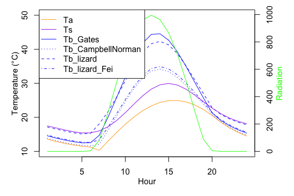

```r
par(mar = c(4, 4, 1, 4),
    mgp = c(2, 1, 0),
    las = 0)

# Gates

  plot(x    = 1:24,
       y    = TeGates,
       type = "l",
       xlab = "Hour",
       ylab = "Temperature (°C)",
       col = "blue",
       ylim = c(10,50))

# Campbell

  points(x    = 1:24,
         y    = TeCN,
         type = "l",
         col  = "blue",
         lty  = "dotted")

# Buckley 2008

  points(x    = 1:24,
         y    = TeLiz,
         type = "l",
         col  = "blue",
         lty  = "dashed")

# Fei et al.

  points(x    = 1:24,
         y    = TeFei,
         type = "l",
         col  = "blue",
         lty  = "dotdash")

points(x    = 1:24,
       y    = Ta,
       type = "l",
       col  = "orange")

points(x    = 1:24,
       y    = Ts,
       type = "l",
       col  = "purple")

# add additional axis with radiation

  par(new = TRUE)

  plot(x    = 1:24,
       y    = Sdir,
       pch  = 16,
       axes = FALSE,
       xlab = NA,
       ylab = NA,
       type = "l",
       col  = "green")

  axis(side = 4)

  mtext(side = 4,
        line = 2,
        text = "Radiation",
        col  = "green")

legend(x      = "topleft",
       legend = c("Ta", "Ts", "Tb_Gates", "Tb_CampbellNorman", "Tb_lizard", "Tb_lizard_Fei"),
       lty    = c("solid", "solid", "solid", "dotted", "dashed", "dotdash"),
       pch    = NA,
       col    = c("orange", "purple", "blue", "blue", "blue", "blue"))
```

## Energy balance

We will now use body temperature estimates to examine the components of the energy balance. We will be solving the following energy balance:

$$Q_{net} = Q_{abs} - Q_{emit} - Q_{conv} - Q_{cond} + Q_{met} - Q_{evap}.$$

We will estimate each term on the right side of the equation in turn. We calculate the hourly radiation absorbed as follows:

```r
Qabs <- rep(NA, 24)

for (hr in 1:24) {
  Qabs[hr] <- Qradiation_absorbed(a       = a,
                                  A       = A,
                                  psa_dir = psa[hr],
                                  psa_dif = 0.5,
                                  psa_ref = 0.5-psa_g,
                                  S_dir   = Sdir[hr],
                                  S_dif   = Sdif[hr],
                                  rho     = rho)
}
```

We estimate thermal radiation $Q_{emit}$ for the lizard outdoors. We assume the surface emissivity of lizards, $\epsilon_s = 0.965$ (Barlett and Gates 1967).

```r
# Use Gates model as Te estimate

  Te <- TeGates

Qemit <- rep(NA, 24)

for (hr in 1:24) {
  Qemit[hr] <- Qemitted_thermal_radiation(epsilon  = epsilon_s,
                                          A        = A,
                                          psa_dir  = 0.5,
                                          psa_ref  = 0.5-psa_g,
                                          T_b      = Te[hr] + 273,
                                          T_g      = Ts[hr] + 273,
                                          T_a      = Ta[hr] + 273,
                                          enclosed = FALSE)
}
```

We next estimate convection $Q_{conv}$ and conduction $Q_{cond}$. We estimate convective heat exchange between the animal and surrounding air using the following relationship:

$$Q_{conv}= ef\cdot H_L(A\cdot \mbox{proportion})(T_{aK}-T_{bK}),$$

where an enhancement factor, $ef$, multiplier can be incorporated to account for increases in heat exchange resulting from air turbulence in field conditions.

The function is available in R assuming that 2/3 of the lizard’s surface area is exchanging heat through convection.

```r
Qconv <- rep(NA, 24)

for (hr in 1:24) {
  Qconv[hr] <- Qconvection(T_a        = Ta[hr] + 273.15,
                           T_b        = Te[hr] + 273.15,
                           H          = H_L,
                           A          = A,
                           proportion = 0.67,
                           ef         = 1.3)
}
```

We estimate conductance between the lizard and surface assuming conductance through the animal tissue is the rate limiting step as follows:

$$Q_{cond}= A\cdot \mbox{proportion}\cdot K(T_{gK}-T_{bK})/d.$$

We conduct the estimate in R assuming that conductive heat exchange occurs down to a soil depth of 2.5cm. We use this value rather than skin thickness, which results in rapid conduction and does not readily reach steady state conditions.

```r
Qcond <- rep(NA, 24)

for (hr in 1:24) {
  Qcond[hr] <- Qconduction_animal(T_g        = Ts[hr] + 273,
                                  T_b        = Te[hr] + 273,
                                  d          = 0.025, #assume for conductive heat exchange occurs down to 2.5cm
                                  K          = 0.5,
                                  A          = A,
                                  proportion = psa_g)
}
```

We assume, as in generally done for lizards, that heat exchange associated with metabolism and evaporation is negligible, but we note that functions for estimating each heat exchange are described above.

```r
Qmet  <- 0
Qevap <- 0
```

The full heat budget can be calculated as follows. We plot out the energy balance components.

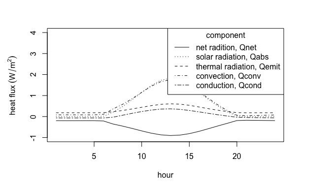

```r
Qnet <- Qnet_Gates(Qabs  = Qabs,
                   Qemit = Qemit,
                   Qconv = Qconv,
                   Qcond = Qcond,
                   Qmet  = Qmet,
                   Qevap = Qevap)

par(mar = c(5, 5, 3, 5))

plot(x    = 1:24,
     y    = Qnet,
     type = "l",
     xlab = "hour",
     ylab = expression("heat flux" ~ (W/m^{2})),
     ylim = c(-1,4))

points(x    = 1:24,
       y    = Qabs,
       type = "l",
       lty  = "dotted")

points(x    = 1:24,
       y    = Qemit,
       type = "l",
       lty  = "dashed")

points(x    = 1:24,
       y    = Qconv,
       type = "l",
       lty  = "dotdash")

points(x    = 1:24,
       y    = Qcond,
       type = "l",
       lty  = "twodash")

legend(x      = "topright",
       title  = "component",
       legend = c("net radition, Qnet", "solar radiation, Qabs", "thermal radiation, Qemit", "convection, Qconv", "conduction, Qcond"),
       lty    = c("solid", "dotted", "dashed", "dotdash", "twodash"))
```

# References

Anderson, R. V., C. R. Tracy, and Z. Abramsky. 1979. “Habitat Selection in Two Species of Short-Horned Grasshoppers.” *Oecologia* 38 (3): 359–74.

Bakken, G. S. 1992. “Measurement and Application of Operative and Standard Operative Temperatures in Ecology.” *American Zoologist* 32 (2): 194–216.

Barlett, P. N., and D. M. Gates. 1967. “The Energy Budget of a Lizard on a Tree Trunk.” *Ecology* 48 (2): 315–22.

Buckley, L. B. 2007. “Linking Traits to Energetics and Population Dynamics to Predict Lizard Ranges in Changing Environments.” *The American Naturalist* 171 (1): E1–19.

Buckley, L. B., and J. G. Kingsolver. 2012. “The Demographic Impacts of Shifts in Climate Means and Extremes on Alpine Butterflies.” *Functional Ecology* 26 (4): 969–77.

Buckley, L. B., C. R. Nufio, and J. G. Kingsolver. 2014. “Phenotypic Clines, Energy Balances and Ecological Responses to Climate Change.” *Journal of Animal Ecology* 83 (1): 41–50.

Campbell, G. S., and J. Norman. 2012. *An Introduction to Environmental Biophysics*. Springer Science & Business Media.

Denny, M. W. 1993. *Air and Water: The Biology and Physics of Life’s Media*. Princeton University Press.

Denny, M. W., and C. D. G. Harley. 2006. “Hot Limpets: Predicting Body Temperature in a Conductance-Mediated Thermal System.” *Journal of Experimental Biology* 209 (13): 2409–19.

Erbs, D. G., S. A. Klein, and J. A. Duffie. 1982. “Estimation of the Diffuse Radiation Fraction for Hourly, Daily and Monthly-Average Global Radiation.” *Solar Energy* 28 (4): 293–302.

Fei, T., A.w K. Skidmore, V. Venus, T. Wang, M. Schlerf, B. Toxopeus, S. Van Overjijk, M. Bian, and Y. Liu. 2012. “A Body Temperature Model for Lizards as Estimated from the Thermal Environment.” *Journal of Thermal Biology* 37 (1): 56–64.

Forsythe, W. C., E. J. Rykiel Jr., R. S. Stahl, H. Wu, and R. M. Schoolfield. 1995. “A Model Comparison for Daylength as a Function of Latitude and Day of Year.” *Ecological Modeling* 80 (1): 87–95.

Galushko, D., N. Ermakov, M. Karpovski, A. Palevski, J. S. Ishay, and D. J. Bergman. 2005. “Electrical, Thermoelectric and Thermophysical Properties of Hornet Cuticle.” *Semiconductor Science and Technology* 20 (3): 286.

Gates, D. M. 2012. *Biophysical Ecology*. Courier Corporation.

Gillooly, J. F., J. H. Brown, G. B. West, V. M. Savage, and E. L. Charnov. 2001. “Effects of Size and Temperature on Metabolic Rate.” *Science* 293 (5538): 2248–51.

Helmuth, B. 1999. “Thermal Biology of Rocky Intertidal Mussels: Quantifying Body Temperatures Using Climatological Data.” *Ecology* 80 (1): 15–34.

Helmuth, B. S. T. 1998. “Intertidal Mussel Microclimates: Predicting the Body Temperature of a Sessile Invertebrate.” *Ecological Monographs* 68 (1): 51–74.

Kingsolver, J. G. 1983. “Thermoregulation and Flight in Colias Butterflies: Elevational Patterns and Mechanistic Limitations.” *Ecology* 64 (3): 534–45.

Lactin, D. J., and D. L. Johnson. 1998. “Environmental, Physical, and Behavioural Determinants of Body Temperature in Grasshopper Nymphs (Orthoptera: Acrididae).” *The Canadian Entomologist* 130 (5): 551–77.

Liu, B. Y. H., and R. C. Jordan. 1960. “The Interrelationship and Characteristic Distribution of Direct, Diffuse and Total Solar Radiation.” *Solar Energy* 4 (3): 1–19.

Mislan, K. A. S., and D. S. Wethey. 2015. “A Biophysical Basis for Patchy Mortality During Heat Waves.” *Ecology* 96 (4): 902–7.

Mitchell, John W. 1976. “Heat Transfer from Spheres and Other Animal Forms.” *Biophysical Journal* 16 (6): 561–69.

Muth, A. 1977. “Thermoregulatory Postures and Orientation to the Sun: A Mechanistic Evaluation for the Zebra-Tailed Lizard, Callisaurus Draconoides.” *Copeia*, 710–20.

Norris, K. S. 1967. “Color Adaptation in Desert Reptiles and Its Thermal Relationships.” In *Lizard Ecology: A Symposium*, 162–229. University of Missouri Press Columbia.

Pennell, S., and J. Deignan. 1989. “Computing the Projected Area of a Cone.” *SIAM Review* 31 (2): 299–302.

Porter, W. P., and F. C. James. 1979. “Behavioral Implications of Mechanistic Ecology II: The African Rainbow Lizard, Agama Agama.” *Copeia*, 594–619.

Porter, W. P., J. W. Mitchell, W. A. Beckman, and C. B. DeWitt. 1973. “Behavioral Implications of Mechanistic Ecology.” *Oecologia* 13 (1): 1–54.

Riddell, E. A., J. P. Odom, J. D. Damm, and M. W. Sears. 2018. “Plasticity Reveals Hidden Resistance to Extinction Under Climate Change in the Global Hotspot of Salamander Diversity.” *Science Advances* 4 (7): eaar5471.

Roughgarden, J., W. Porter, and D. Heckel. 1981. “Resource Partitioning of Space and Its Relationship to Body Temperature in Anolis Lizard Populations.” *Oecologia* 50 (2): 256–64.

Samietz, J., M. A. Salser, and H. Dingle. 2005. “Altitudinal Variation in Behavioural Thermoregulation: Local Adaptation Vs. Plasticity in California Grasshoppers.” *Journal of Evolutionary Biology* 18 (4): 1087–96.

Spotila, J. R., M. P. O’Connor, and G. S. Bakken. 1992. “Biophysics of Heat and Mass Transfer.” *Environmental Physiology of the Amphibians. University of Chicago Press, Chicago*, 59–80.

Swinbank, W. C. 1963. “Long-Wave Radiation from Clear Skies.” *Quarterly Journal of the Royal Meteorological Society* 89 (381): 339–48.